# Mixing text + computations

Markdown, quarto, webpages, pandoc

Author

Denis Schluppeck

Session date:

## Motivation

- often useful to produce short documents that mix code snippets, plots, text, images
- could use PPT, Keynote, Word (but don’t play nicely with version control)
- use a simple text based version

## Where would you use this?

- teaching (content changes slightly/a lot) each year
- research: publishing data + code is now a *must* for many journals
- after this walk-through, it would be great to discuss if people find this useful?! What for?

## `markdown` is widely used

- if you want some *light markup*
- go **beyond simple text**
- a couple of key things like
- [easy to write links](https://www.google.com)

## … images

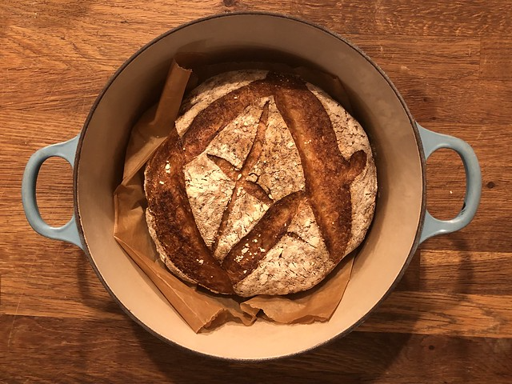

some bread in a dutch oven

## Maths, equations are easy

$$\chi^2 = \sum_i \Big( \frac{y_i-y(x_i; a_1\dots, a_M )}{\sigma_i} \Big)^2$$

an online editor at [stackedit](https://stackedit.io/), to just have a play

## Challenges

- placing images where you want them (arbitrarily on page) requires some work
- you need to render / transform it (only seconds, but not instantaneous)
- if you make mistakes you (it’s a very light version of coding)
- if you link to local files (images, etc), you have to remember to move them along (not a problem if everything is online)

## Advantages

- markdown (itself) structures your documents
- can easily be **tranformed** into `pdf`, `pptx`, `docx`, `revealjs`, etc.
- gets rendered nicely on `github.com`, by defauilt
- easy to edit, rules are simple to learn
- you can add in `computations` code in `r`, `python`, `julia` et al and make them part of your documents $\rightarrow$ `quarto`

## quick demo

- `VSCode` with markdown plugin (linting, preview)
- (! the `github.com` repo which gets rendered using a tool called `jekyll` under the hood)

## `quarto`

- a command line tool that renders a flavour of markdown called `qmd` (quarto-markdow)
- a superset of markdown, so any previous work should be ok
- by adding some additional info at top of document, you can opt into lots of good stuff

## info at top: `YAML`

A text block delimited by `---`, key/value

```yaml
---
title: "Mixing text + computations"
subtitle: "Markdown, quarto, webpages, pandoc"
author: Denis Schluppeck
date: 2023-01-18
format:
  revealjs:
    mainfont: Helvetica
    sansfont: Helvetica
---
```

## `quarto`

- if you like `RStudio`, there is a nice interface
- `VScode` has a plugin that works well
- or if you prefer `emacs/vim/nano/TextEdit`, the command line tool is not that hard to use.

```bash
quarto preview test.qmd
# or render
quarto render test.qmd --to pdf
```

## Links

- https://quarto.org/
- https://rstudio.org/ - now pos.it: https://posit.co/
- the original proposal for markdown: https://daringfireball.net/projects/markdown/
- https://code.visualstudio.com/ - visual studio code (free download)

### related ideas

- literate programming
- Matlab / `publish()`
- notebooks, `Pluto.jl`